# Análisis de supervivencia

Carlos Muñoz Díaz

5/1/2022

El objetivo de este trabajo -realizado con R Markdown- es desarrollar un análisis de datos de dos bases de datos a partir de un análisis de supervivencia (a partir del método de Kaplan-Maier y la regresión de Cox) y, tras ello, ofrecer una interpretación para los distintos resultados obtenidos.

En primer lugar, se instalan y disponen los paquetes necesarios para el análisis (el paquete ‘survival’ y el paquete ‘tidyverse’), se descargan los datos necesarios y se transforman para que sean de tipo *survival*.

Con los datos dispuestos, primero se replica -con algunas modificaciones- el análisis sobre la base de datos ‘whas500’, utilizada por el profesor durante la sesión del máster.

# WHAS500

## Análisis de Kaplan-Maier (con whas500 y sin variables)

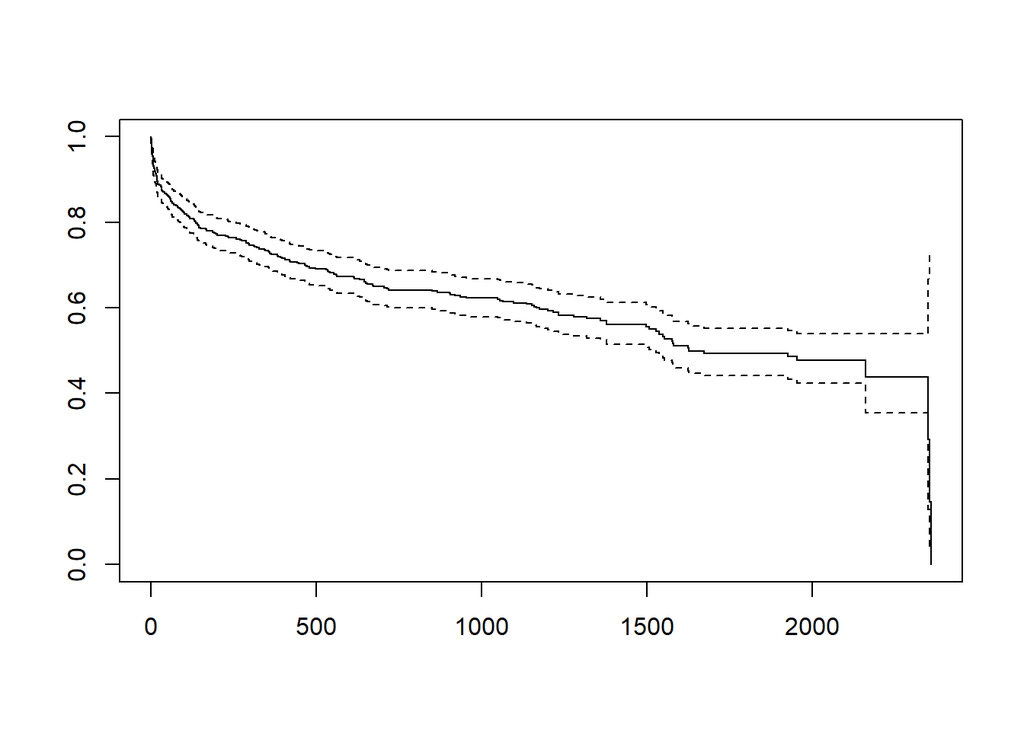

```r
# Visualización
survfit_one <- survfit(whas500 ~ 1)
plot(survfit_one)
```

```r
# Resumen
sum_one <- survfit(Surv(whas500_aux$lenfol, whas500_aux$fstat) ~ 1, data = whas500_aux)
print(sum_one)
```

```
## Call: survfit(formula = Surv(whas500_aux$lenfol, whas500_aux$fstat) ~
##     1, data = whas500_aux)
##
##        n events median 0.95LCL 0.95UCL
## [1,] 500    215   1627    1527      NA
```

En este resumen se observa que, de las 500 observaciones iniciales, quedan 215 no censuradas. La mediana de la supervivencia se alcanza a los 1.627 días (4,45 años). Esto significa que, llegado el día 1.627 del análisis, **la mitad de las observaciones no censuradas continúan vivas**.

```r
# Supervivencia tras 1 y 3 años
sum_one_1y <- summary(survfit(Surv(whas500_aux$lenfol, whas500_aux$fstat) ~ 1, data = whas500_aux), times = 365.25)
print(sum_one_1y)
```

```
## Call: survfit(formula = Surv(whas500_aux$lenfol, whas500_aux$fstat) ~
##     1, data = whas500_aux)
##
##  time n.risk n.event survival std.err lower 95% CI upper 95% CI
##   365    362     138    0.724    0.02        0.686        0.764
```

```r
sum_one_3y <- summary(survfit(Surv(whas500_aux$lenfol, whas500_aux$fstat) ~ 1, data = whas500_aux), times = 365.25*3)
print(sum_one_3y)
```

```
## Call: survfit(formula = Surv(whas500_aux$lenfol, whas500_aux$fstat) ~
##     1, data = whas500_aux)
##
##  time n.risk n.event survival std.err lower 95% CI upper 95% CI
##  1096    226     182    0.614  0.0229        0.571        0.661
```

Las dos observaciones representadas en este sector muestran la supervivencia pasado 1 y 3 años del seguimiento. Pasado un año, **el 72,4% de las observaciones siguen vivas**. Pasados tres años, **todavía continúan vivas el 61,4% de las observaciones**.

Estos datos son lógicos tras fijarse en el primer gráfico y en el análisis previo, donde se indicaba que la mitad de las observaciones seguían vivas pasados 4,45 años.

## Análisis de Kaplan-Maier (con whas500 y con variable género)

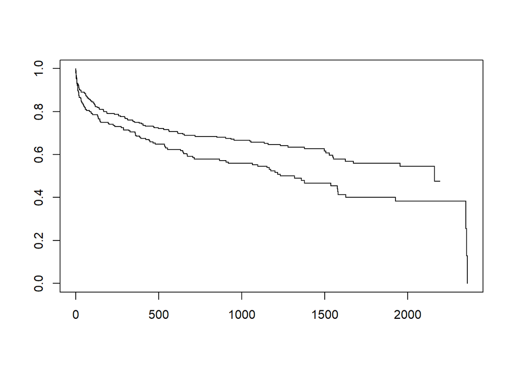

```r
# Visualización
survfit_gender <- survfit(whas500 ~ gender, data = whas500_aux)
plot(survfit_gender)
```

Aunque este sencillo gráfico no cuenta con leyenda, la línea superior representa al sexo masculino y la línea inferior, al femenino.

Tras un primer vistazo se observa que los hombres tienen una mejor supervivencia que las mujeres. Esto también se reflejará en los siguientes sectores donde se continúa ofreciendo un análisis basado en Kaplan-Maier, pero como ya reflejó en su momento el profesor, esto no es del todo cierto: **la variable ‘género’ no explica la supervivencia de las observaciones**.

```r
# Resumen de datos
sum_gender <- survfit(Surv(whas500_aux$lenfol, whas500_aux$fstat) ~ gender, data = whas500_aux)
print(sum_gender)
```

```
## Call: survfit(formula = Surv(whas500_aux$lenfol, whas500_aux$fstat) ~
##     gender, data = whas500_aux)
##
##            n events median 0.95LCL 0.95UCL
## gender=0 300    111   2160    1671      NA
## gender=1 200    104   1317     905    1627
```

La mediana de supervivencia **para los hombres es de 2.160 días (5,9 años)**, mientras que **para las mujeres es de 1.317 días (3,6 años)**.

```r
# Supervivencia tras 1 y 3 años
sum_gender_1y <- summary(survfit(Surv(whas500_aux$lenfol, whas500_aux$fstat) ~ gender, data = whas500_aux), times = 365.25)
print(sum_gender_1y)
```

```
## Call: survfit(formula = Surv(whas500_aux$lenfol, whas500_aux$fstat) ~
##     gender, data = whas500_aux)
##
##                 gender=0
##         time       n.risk      n.event     survival      std.err lower 95% CI
##      365.250      225.000       75.000        0.750        0.025        0.703
## upper 95% CI
##        0.801
##
##                 gender=1
##         time       n.risk      n.event     survival      std.err lower 95% CI
##     365.2500     137.0000      63.0000       0.6850       0.0328       0.6236
## upper 95% CI
##       0.7525
```

```r
sum_gender_3y <- summary(survfit(Surv(whas500_aux$lenfol, whas500_aux$fstat) ~ gender, data = whas500_aux), times = 365.25*3)
print(sum_gender_3y)
```

```
## Call: survfit(formula = Surv(whas500_aux$lenfol, whas500_aux$fstat) ~
##     gender, data = whas500_aux)
##
##                 gender=0
##         time       n.risk      n.event     survival      std.err lower 95% CI
##     1.10e+03     1.42e+02     9.70e+01     6.57e-01     2.88e-02     6.03e-01
## upper 95% CI
##     7.16e-01
##
##                 gender=1
##         time       n.risk      n.event     survival      std.err lower 95% CI
##     1.10e+03     8.40e+01     8.50e+01     5.52e-01     3.68e-02     4.85e-01
## upper 95% CI
##     6.29e-01
```

## Análisis de Kaplan-Maier (p-value en género)

```r
sd <- survdiff(Surv(whas500_aux$lenfol, whas500_aux$fstat) ~ gender, data = whas500_aux)
pvalue <- 1 - pchisq(sd$chisq, length(sd$n) - 1)
print(pvalue)
```

```
## [1] 0.0052503
```

Antes del análisis a partir de la regresión, muestro el p-value para el género. **Este 0,005 indica que es significativo**.

## Regresión de Cox (con whas500 y univariante con género)

```r
# Regresión de Cox con género
cox_gender <- coxph(Surv(whas500_aux$lenfol, whas500_aux$fstat) ~ gender, data = whas500_aux)
summary(cox_gender)
```

```
## Call:
## coxph(formula = Surv(whas500_aux$lenfol, whas500_aux$fstat) ~
##     gender, data = whas500_aux)
##
##   n= 500, number of events= 215
##
##          coef exp(coef) se(coef)     z Pr(>|z|)
## gender 0.3815    1.4645   0.1376 2.773  0.00556 **
## ---
## Signif. codes:  0 '***' 0.001 '**' 0.01 '*' 0.05 '.' 0.1 ' ' 1
##
##        exp(coef) exp(-coef) lower .95 upper .95
## gender     1.464     0.6828     1.118     1.918
##
## Concordance= 0.542  (se = 0.018 )
## Likelihood ratio test= 7.6  on 1 df,   p=0.006
## Wald test            = 7.69  on 1 df,   p=0.006
## Score (logrank) test = 7.78  on 1 df,   p=0.005
```

Al igual que en el análisis previo, la regresión de Cox muestra que **el género es significante ya que el p-value aquí es de 0,0056**.

Igualmente, la variable *exp(coef)* nos indica que **las mujeres tienen un 46% más de probabilidades de morir que los hombres**.

Pero, ¿qué pasa cuando realizamos un análisis multivariante incluyendo otras variables de la base de datos?

## Regresión de Cox (con whas500 y multivariante con género, edad y diasbp (presión arterial inicial))

```r
# Regresión de Cox con tres variables
cox_multi <- coxph(Surv(whas500_aux$lenfol, whas500_aux$fstat) ~ gender + age + diasbp, data =  whas500_aux)
summary(cox_multi)
```

```
## Call:
## coxph(formula = Surv(whas500_aux$lenfol, whas500_aux$fstat) ~
##     gender + age + diasbp, data = whas500_aux)
##
##   n= 500, number of events= 215
##
##             coef exp(coef)  se(coef)      z Pr(>|z|)
## gender -0.088257  0.915526  0.140797 -0.627   0.5308
## age     0.063386  1.065438  0.006262 10.122   <2e-16 ***
## diasbp -0.008609  0.991428  0.003512 -2.451   0.0142 *
## ---
## Signif. codes:  0 '***' 0.001 '**' 0.01 '*' 0.05 '.' 0.1 ' ' 1
##
##        exp(coef) exp(-coef) lower .95 upper .95
## gender    0.9155     1.0923    0.6947    1.2065
## age       1.0654     0.9386    1.0524    1.0786
## diasbp    0.9914     1.0086    0.9846    0.9983
##
## Concordance= 0.737  (se = 0.017 )
## Likelihood ratio test= 148.5  on 3 df,   p=<2e-16
## Wald test            = 129.4  on 3 df,   p=<2e-16
## Score (logrank) test = 135.8  on 3 df,   p=<2e-16
```

Los resultados aquí obtenidos contradicen todo el análisis anterior. Cuando se observa junto a la edad y a la presión arterial inicial, el género femenino tiene un 9% menos de posibilidades de morir que los hombres. No obstante, no debemos fijarnos en esta cifra: **en un análisis multivariante, el género deja de ser significativo (con un p-value de 0,53)**.

Aunque podríamos haber seleccionado más variables (u otras variables), nos quedamos con la edad y con la presión arterial inicial.

Tras este análisis, **la variable ‘edad’ es bastante significativa** (con un p-value muy inferior a 0,0001). Con cada año cumplido, **las posibilidades de morir aumentan en un 6%**. Es decir, una persona con 35 años tiene más probabilidades de morir que una de 30.

La presión arterial inicial, por su parte, es ligeramente significativa (con un p-value de 0,0142). No obstante, aquí me surgen dudas de interpretación a primera vista: ¿cuánta menos presión arterial inicial tienes menos probabilidad de morir? ¿O es al revés?

Para intentar buscar una respuesta, recurro a la categorización de la variable, similar al proceso que siguió el profesor con la variable ‘bmi’.

```r
whas500_aux <- whas500_aux %>%
  mutate(
    diasbp_cat = case_when(
      diasbp < 63 ~ "first_q",
      diasbp < 79 ~ "second_q",
      diasbp < 91.25 ~ "third_q",
      diasbp < 198.1 ~ 'fourth_q',
      TRUE ~ as.character(diasbp)
    )
  )

cox_multi_2 <- coxph(Surv(whas500_aux$lenfol, whas500_aux$fstat) ~ gender + age + diasbp_cat, data =  whas500_aux)
summary(cox_multi_2)
```

```
## Call:
## coxph(formula = Surv(whas500_aux$lenfol, whas500_aux$fstat) ~
##     gender + age + diasbp_cat, data = whas500_aux)
##
##   n= 500, number of events= 215
##
##                         coef exp(coef)  se(coef)      z Pr(>|z|)
## gender             -0.069360  0.932991  0.141390 -0.491   0.6237
## age                 0.062765  1.064776  0.006233 10.069   <2e-16 ***
## diasbp_catfourth_q -0.455904  0.633875  0.205874 -2.214   0.0268 *
## diasbp_catsecond_q -0.304783  0.737283  0.177905 -1.713   0.0867 .
## diasbp_catthird_q  -0.453228  0.635573  0.197020 -2.300   0.0214 *
## ---
## Signif. codes:  0 '***' 0.001 '**' 0.01 '*' 0.05 '.' 0.1 ' ' 1
##
##                    exp(coef) exp(-coef) lower .95 upper .95
## gender                0.9330     1.0718    0.7072    1.2309
## age                   1.0648     0.9392    1.0518    1.0779
## diasbp_catfourth_q    0.6339     1.5776    0.4234    0.9490
## diasbp_catsecond_q    0.7373     1.3563    0.5202    1.0449
## diasbp_catthird_q     0.6356     1.5734    0.4320    0.9351
##
## Concordance= 0.738  (se = 0.017 )
## Likelihood ratio test= 149.6  on 5 df,   p=<2e-16
## Wald test            = 133.5  on 5 df,   p=<2e-16
## Score (logrank) test = 141.5  on 5 df,   p=<2e-16
```

La categoría ‘first_q’ de la variable ‘diasbp_cat’ nos sirve para compara y observar el comportamiento del resto de categorías. Y en comparación con dicha categoría (que representa las observaciones con las presiones arteriales iniciales más bajas), el hazard ratio (o **exp(coef)**) es menor en todas ellas.

*(Este último análisis me genera ciertas dudas de interpretación de los resultados > ¿Cómo diferenciar significatividad, correlación, causa-efecto? ¿Cómo llegar a una interpretación más real, más ajustada de los resultados? No creo que cuanto la variable ‘diasbp’ sea ni mucho menos determinante, pero los resultados arrojan cierta significativad. ¿Por qué?*

*Preguntar a Stanislao cuando volvamos al CCHS)*

## —

Como tercer ejercicio (el primero fue el análisis de los datos simples de WHAS500 y el segundo, la incorporación de una variable como ‘diasbp’), se analiza la base de datos ‘veteran’, del paquete mencionado ‘survival’.

Como en el apartado anterior, se analiza los datos a partir de un análisis de supervivencia y se ofrecen interpretaciones para los resultados obtenidos.

# Base de datos ‘veteran’

Estos datos pertenecen al paquete de ‘survival’ y el significado de cada columna se puede encontrar en la [documentación del paquete](https://cran.r-project.org/web/packages/survival/index.html).

La base de datos está compuesta por 137 observaciones y 8 columnas. Lo que me ha llevado a utilizarla es que no tiene columna de ‘género’ (que son los ejemplos más claros y simples con lo que empezar a hacer análisis de este estilo), por lo que puede me obliga a trabajar con otro tipo de variables.

## Análisis de Kaplan-Maier (con veteran y sin variables)

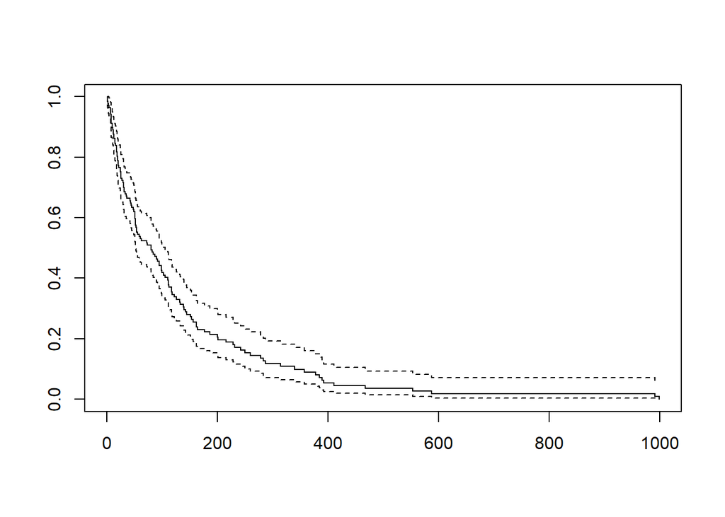

```r
# Visualización
survfit_vet <- survfit(veteran ~ 1)
plot(survfit_vet)
```

La visualización permite observar una **fuerte caída de la supervivencia desde el primer momento hasta el día 180, más o menos**. Desde ese día hasta el 380-390, la caída sigue siendo fuerte pero no llega a los niveles previos. Y tras ese día, la curva comienza a aplanarse hasta el día 580, donde ya termina de aplanarse del todo.

```r
# Resumen
sum_vet <- survfit(Surv(veteran_aux$time, veteran_aux$status) ~ 1, data = veteran_aux)
print(sum_vet)
```

```
## Call: survfit(formula = Surv(veteran_aux$time, veteran_aux$status) ~
##     1, data = veteran_aux)
##
##        n events median 0.95LCL 0.95UCL
## [1,] 137    128     80      52     105
```

En este resumen se indica que **la mediana se sitúa en el día 80**. En un primer momento, me parece curioso que solo la mitad de las observaciones continúen vivas en apenas 80 días pero el seguimiento se prolongue hasta el día 1.000, más o menos.

Por ello, recurro a un segundo resumen más específico.

```r
# Segundo resumen
summary(veteran_aux$time)
```

```
##    Min. 1st Qu.  Median    Mean 3rd Qu.    Max.
##     1.0    25.0    80.0   121.6   144.0   999.0
```

```r
head(sort(veteran_aux$time,decreasing=TRUE), n = 10)
```

```
##  [1] 999 991 587 553 467 411 392 389 384 378
```

Con este segundo resumen ya se puede observar la existencia de dos valores ‘time’ muy extraños y separados del resto: 999 y 991 frente a 587, que es el tercero. A lo mejor tendría que realizar un análisis más exhaustivo para detectar si son *caveats*, *outliers* o errores.

```r
# Supervivencia tras 1 y 3 años
sum_vet_1y <- summary(survfit(Surv(veteran_aux$time, veteran_aux$status) ~ 1, data = veteran_aux), times = 365.25, extend = TRUE)
print(sum_vet_1y)
```

```
## Call: survfit(formula = Surv(veteran_aux$time, veteran_aux$status) ~
##     1, data = veteran_aux)
##
##  time n.risk n.event survival std.err lower 95% CI upper 95% CI
##   365     10     118     0.09  0.0265       0.0506         0.16
```

```r
sum_vet_2y <- summary(survfit(Surv(veteran_aux$time, veteran_aux$status) ~ 1, data = veteran_aux), times = 365.25*2, extend = TRUE)
print(sum_vet_2y)
```

```
## Call: survfit(formula = Surv(veteran_aux$time, veteran_aux$status) ~
##     1, data = veteran_aux)
##
##  time n.risk n.event survival std.err lower 95% CI upper 95% CI
##   730      2     126    0.018  0.0126      0.00459       0.0707
```

```r
sum_vet_3y <- summary(survfit(Surv(veteran_aux$time, veteran_aux$status) ~ 1, data = veteran_aux), times = 365.25*3, extend = TRUE)
print(sum_vet_3y)
```

```
## Call: survfit(formula = Surv(veteran_aux$time, veteran_aux$status) ~
##     1, data = veteran_aux)
##
##  time n.risk n.event survival std.err lower 95% CI upper 95% CI
##  1096      0     128        0     NaN           NA           NA
```

Tras un año de seguimiento, *tan solo quedan con vida un 9% de las observaciones*. Tras dos años, *un 1,8%*. Y tras tres años, *un 0%*, algo lógico viendo los varoles mostrados de forma previa.

Tras este primer análisis genérico sobre, he decidido trabajar principalmente la columna ‘celltype’, que contiene cuatro categorías (squamos, smallcell, adeno, large).

## Análisis de Kaplan-Maier (con veteran y con variable celltype (tipo de tratamiento))

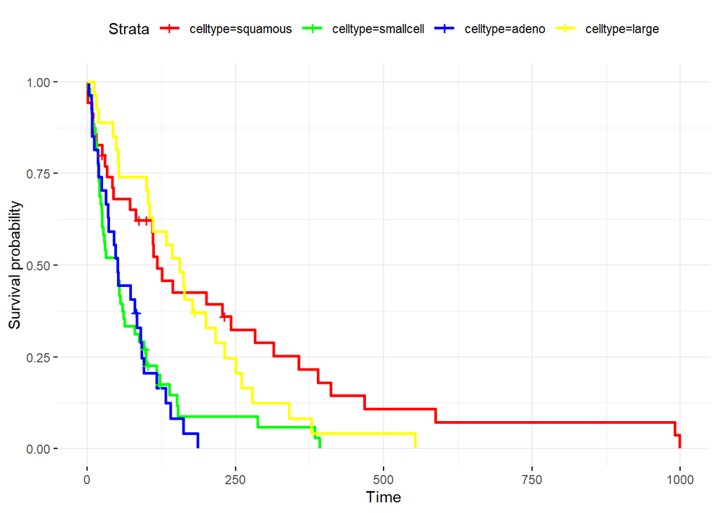

```r
survfit_celltype <- survfit(veteran ~ celltype, data = veteran_aux)
ggsurvplot(survfit_celltype,
           pval = FALSE,
           conf.int = FALSE,
           ggtheme = theme_minimal(), # Change ggplot2 theme
           palette = c("red", "green", 'blue', 'yellow'))
```

En esta visualización, en la que he tenido que recurrir a una librería externa para mostrar las diferentes categorías, se observa cómo, al principio, las observaciones con celltype *large* tiene una mejor supervivencia. Sin embargo, a partir del día 180-200, son las observaciones con celltype *squamos* las que registran una mejor supervivencia.

```r
# Resumen de datos
sum_celltype <- survfit(Surv(veteran_aux$time, veteran_aux$status) ~ celltype, data = veteran_aux)
print(sum_celltype)
```

```
## Call: survfit(formula = Surv(veteran_aux$time, veteran_aux$status) ~
##     celltype, data = veteran_aux)
##
##                     n events median 0.95LCL 0.95UCL
## celltype=squamous  35     31    118      82     314
## celltype=smallcell 48     45     51      25      63
## celltype=adeno     27     26     51      35      92
## celltype=large     27     26    156     105     231
```

En este resumen destaca cómo la mitad de las observaciones con *large* continúan vivas en el día 156 mientras que la mediana para *squamos* es de 118 días. Pero como se ha visto en el gráfico anterior, las restantes con *squamos* permanecen más tiempo vivas que aquellas con *large*.

```r
# Supervivencia tras 1 y 3 años
sum_celltype_1y <- summary(survfit(Surv(veteran_aux$time, veteran_aux$status) ~ celltype, data = veteran_aux), times = 365.25, extend = TRUE)
print(sum_celltype_1y)
```

```
## Call: survfit(formula = Surv(veteran_aux$time, veteran_aux$status) ~
##     celltype, data = veteran_aux)
##
##                 celltype=squamous
##         time       n.risk      n.event     survival      std.err lower 95% CI
##     365.2500       6.0000      25.0000       0.2161       0.0757       0.1088
## upper 95% CI
##       0.4294
##
##                 celltype=smallcell
##         time       n.risk      n.event     survival      std.err lower 95% CI
##     365.2500       2.0000      43.0000       0.0585       0.0387       0.0160
## upper 95% CI
##       0.2140
##
##                 celltype=adeno
##         time       n.risk      n.event     survival      std.err lower 95% CI
##          365            0           26            0          NaN           NA
## upper 95% CI
##           NA
##
##                 celltype=large
##         time       n.risk      n.event     survival      std.err lower 95% CI
##     365.2500       2.0000      24.0000       0.0823       0.0553       0.0220
## upper 95% CI
##       0.3073
```

```r
sum_celltype_3y <- summary(survfit(Surv(veteran_aux$time, veteran_aux$status) ~ celltype, data = veteran_aux), times = 365.25*3, extend = TRUE)
print(sum_celltype_3y)
```

```
## Call: survfit(formula = Surv(veteran_aux$time, veteran_aux$status) ~
##     celltype, data = veteran_aux)
##
##                 celltype=squamous
##         time       n.risk      n.event     survival      std.err lower 95% CI
##         1096            0           31            0          NaN           NA
## upper 95% CI
##           NA
##
##                 celltype=smallcell
##         time       n.risk      n.event     survival      std.err lower 95% CI
##         1096            0           45            0          NaN           NA
## upper 95% CI
##           NA
##
##                 celltype=adeno
##         time       n.risk      n.event     survival      std.err lower 95% CI
##         1096            0           26            0          NaN           NA
## upper 95% CI
##           NA
##
##                 celltype=large
##         time       n.risk      n.event     survival      std.err lower 95% CI
##         1096            0           26            0          NaN           NA
## upper 95% CI
##           NA
```

Tras un año de seguimiento, no queda viva ninguna observación con *adeno* y apenas un 5% y un 8% con *smallcell* y *large*, respectivamente. En el caso de *squamos* continúa con vida un 21%.

Y tras tres años, como también se observó de forma previa, no queda ninguna observación con vida.

## Análisis de Kaplan-Maier (p-value en celltype)

```r
sd <- survdiff(Surv(veteran_aux$time, veteran_aux$status) ~ celltype, data = veteran_aux)
pvalue <- 1 - pchisq(sd$chisq, length(sd$n) - 1)
print(pvalue)
```

```
## [1] 1.271246e-05
```

El p-value de la variable ‘celltype’ parece indicar que es una variable con bastante significatividad a la hora de explicar la supervivencia en la base de datos ‘veteran’.

## Regresión de Cox (con veteran y univariante con celltype / trt / prior)

```r
# Regresión de Cox con celltype
cox_celltype <- coxph(Surv(veteran_aux$time, veteran_aux$status) ~ celltype, data = veteran_aux)
summary(cox_celltype)
```

```
## Call:
## coxph(formula = Surv(veteran_aux$time, veteran_aux$status) ~
##     celltype, data = veteran_aux)
##
##   n= 137, number of events= 128
##
##                     coef exp(coef) se(coef)     z Pr(>|z|)
## celltypesmallcell 1.0013    2.7217   0.2535 3.950 7.83e-05 ***
## celltypeadeno     1.1477    3.1510   0.2929 3.919 8.90e-05 ***
## celltypelarge     0.2301    1.2588   0.2773 0.830    0.407
## ---
## Signif. codes:  0 '***' 0.001 '**' 0.01 '*' 0.05 '.' 0.1 ' ' 1
##
##                   exp(coef) exp(-coef) lower .95 upper .95
## celltypesmallcell     2.722     0.3674     1.656     4.473
## celltypeadeno         3.151     0.3174     1.775     5.594
## celltypelarge         1.259     0.7944     0.731     2.168
##
## Concordance= 0.608  (se = 0.028 )
## Likelihood ratio test= 24.85  on 3 df,   p=2e-05
## Wald test            = 24.09  on 3 df,   p=2e-05
## Score (logrank) test = 25.51  on 3 df,   p=1e-05
```

```r
# Regresión de Cox con celltype
cox_trt <- coxph(Surv(veteran_aux$time, veteran_aux$status) ~ trt, data = veteran_aux)
summary(cox_trt)
```

```
## Call:
## coxph(formula = Surv(veteran_aux$time, veteran_aux$status) ~
##     trt, data = veteran_aux)
##
##   n= 137, number of events= 128
##
##        coef exp(coef) se(coef)     z Pr(>|z|)
## trt 0.01774   1.01790  0.18066 0.098    0.922
##
##     exp(coef) exp(-coef) lower .95 upper .95
## trt     1.018     0.9824    0.7144      1.45
##
## Concordance= 0.525  (se = 0.026 )
## Likelihood ratio test= 0.01  on 1 df,   p=0.9
## Wald test            = 0.01  on 1 df,   p=0.9
## Score (logrank) test = 0.01  on 1 df,   p=0.9
```

```r
# Regresión de Cox con celltype
cox_prior <- coxph(Surv(veteran_aux$time, veteran_aux$status) ~ prior, data = veteran_aux)
summary(cox_prior)
```

```
## Call:
## coxph(formula = Surv(veteran_aux$time, veteran_aux$status) ~
##     prior, data = veteran_aux)
##
##   n= 137, number of events= 128
##
##           coef exp(coef) se(coef)      z Pr(>|z|)
## prior -0.01429   0.98581  0.02005 -0.713    0.476
##
##       exp(coef) exp(-coef) lower .95 upper .95
## prior    0.9858      1.014    0.9478     1.025
##
## Concordance= 0.494  (se = 0.025 )
## Likelihood ratio test= 0.52  on 1 df,   p=0.5
## Wald test            = 0.51  on 1 df,   p=0.5
## Score (logrank) test = 0.51  on 1 df,   p=0.5
```

He decidido aplicar la regresión de Cox a tres variables por separado: celltype, trt y prior.

En el caso de **celltype**, la categoría independiente es *squamos*. Y el análisis arroja un resultado significativo para las observaciones con *smallcell* y *adeno*: **presentan, respectivamente, un 172% y 215% más de riesgo de mortalidad** que *squamos* (con unos *exp(coef)* de 2,72 y 3,15). Además, en ambos casos hay una gran significatividad, con un p-value inferior a 0,0001.

Por otro lado, los resultados del análisis para las variables **trt** y **prior** **no ofrecen ninguna significatividad cuando los analizamos por separado**. En ambos casos, el p-valor es superior a 0,1. Es decir, no son determinantes a la hora de explicar la supervivencia en esta base de datos (al menos, por ahora).

## Regresión de Cox (con veteran y multivariante con trt, edad, celltype y prior (si ha sido tratado antes o no))

```r
# Regresión de Cox con cinco variables
cox_multi_vet <- coxph(Surv(veteran_aux$time, veteran_aux$status) ~ celltype + age + trt + prior + diagtime, data =  veteran_aux)
summary(cox_multi_vet)
```

```
## Call:
## coxph(formula = Surv(veteran_aux$time, veteran_aux$status) ~
##     celltype + age + trt + prior + diagtime, data = veteran_aux)
##
##   n= 137, number of events= 128
##
##                        coef exp(coef)  se(coef)      z Pr(>|z|)
## celltypesmallcell  1.040038  2.829326  0.277869  3.743 0.000182 ***
## celltypeadeno      1.188180  3.281104  0.299046  3.973 7.09e-05 ***
## celltypelarge      0.289673  1.335991  0.285337  1.015 0.310012
## age                0.004904  1.004916  0.009646  0.508 0.611198
## trt                0.167443  1.182278  0.201817  0.830 0.406721
## prior             -0.006932  0.993092  0.023173 -0.299 0.764847
## diagtime           0.010149  1.010201  0.009326  1.088 0.276475
## ---
## Signif. codes:  0 '***' 0.001 '**' 0.01 '*' 0.05 '.' 0.1 ' ' 1
##
##                   exp(coef) exp(-coef) lower .95 upper .95
## celltypesmallcell    2.8293     0.3534    1.6412     4.878
## celltypeadeno        3.2811     0.3048    1.8259     5.896
## celltypelarge        1.3360     0.7485    0.7637     2.337
## age                  1.0049     0.9951    0.9861     1.024
## trt                  1.1823     0.8458    0.7960     1.756
## prior                0.9931     1.0070    0.9490     1.039
## diagtime             1.0102     0.9899    0.9919     1.029
##
## Concordance= 0.629  (se = 0.028 )
## Likelihood ratio test= 27.12  on 7 df,   p=3e-04
## Wald test            = 26.51  on 7 df,   p=4e-04
## Score (logrank) test = 28.07  on 7 df,   p=2e-04
```

En la regresión multivariante obtenemos datos similares a los observados de forma previa. En este caso, incluyo una nueva variable (diagtime) para ver si aporta algo a la explicación.

Como ocurría con anterioridad, solo las categorías **smallcell** y **adeno** de *celltype* tienen bastante significatividad en comparación con la variable **squamos** aun entrando otras variables en el análisis.

Las otras variables utilizadas -age, trt, prior y diagtime- no tienen significatividad.

*Seguramente esta base de datos necesite un análisis más profundo sobre las distintas variables para conocer si de verdad la variable ‘celltype’ es tan determinante o si existen otras variables explicativas más importantes.*

*Preguntar a Stanislao a la vuelta al CCHS.*

## —

Por último, añado una referencias que me han sido útiles para entender mejor en qué consiste el análisis de supervivencia, más allá de la clase impartida por el profesor.

# Otras referencias bibliográficas utilizadas

- https://jllopisperez.com/2013/01/07/tema-21-analisis-de-supervivencia/
- http://www.sthda.com/english/wiki/survival-analysis-basics
- http://www.sthda.com/english/wiki/cox-proportional-hazards-model